# Final Project: From Chaos to Clarity: Cleaning and Analyzing Dirty Restaurant Sales Data Using R

# Data Cleaning:

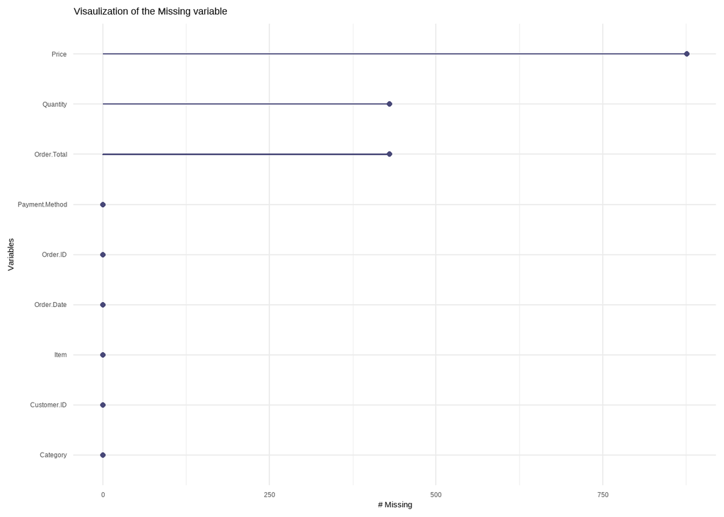

```r
mydata %>%
  gg_miss_var()+
  labs(title = "Visaulization of the Missing variable")
```

```r
sum(!complete.cases(mydata) == T)
```

```
## [1] 876
```

**876 observations** are missing in the dataset. We need to check the pattern of missing and develop a strategy for adjusting the missingness either by omition or imputation method using some machine learning algorithms.

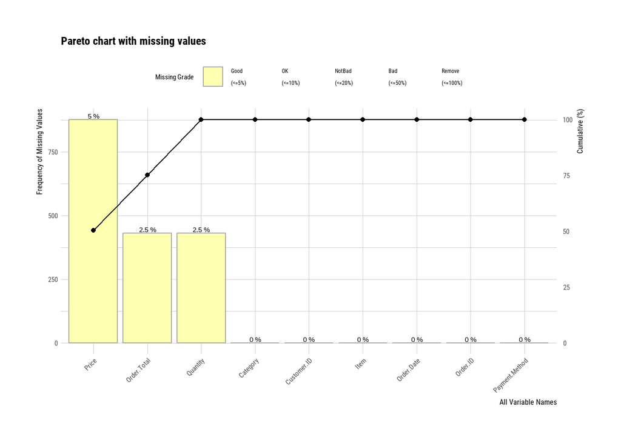

```r
plot_na_pareto(mydata)
```

**Observations:** From the Pareto na missing chart is show that the missing is fair and we can impute and fill the missing observations using machine learning algorithms called **Predictive mean matching**.

```r
# Step 1: Perform multiple imputation
imputed_data <- mice::mice(mydata, method = "pmm")
# Step 2: Extract the completed dataset (e.g., first imputation)
clean_data <- mice::complete(imputed_data, 1)

dim(clean_data)
```

```
## [1] 17534     9
```

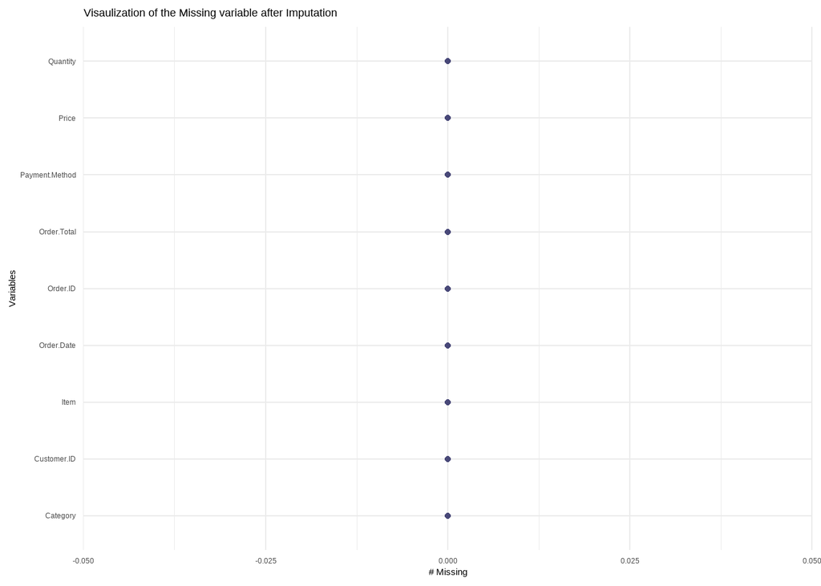

```r
gg_miss_var(clean_data)+
  labs(title = "Visaulization of the Missing variable after Imputation")
```

# Data Analysis:

## Univariate analysis:

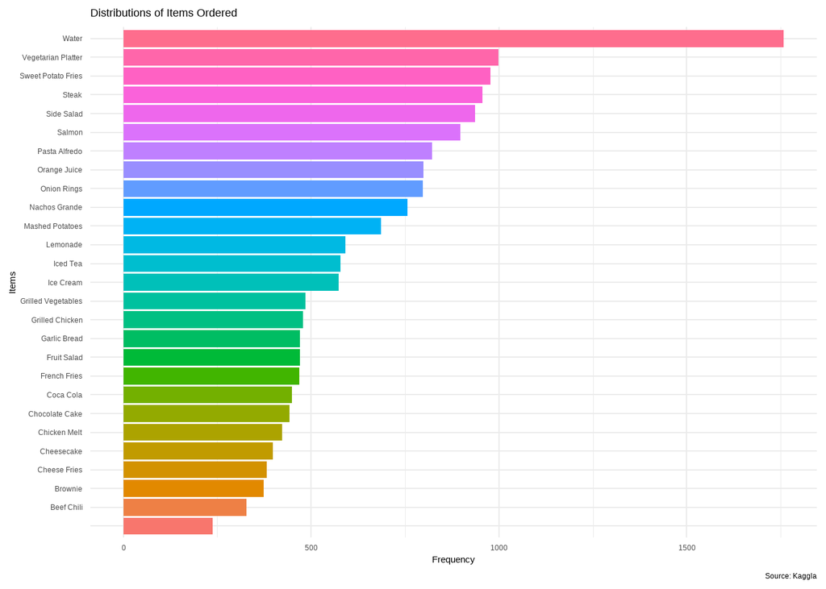

```r
clean_data %>%
  group_by(Item) %>%
  summarise(n = n()) %>%
  ggplot(aes(y = Item, x = sort(n)))+
  geom_bar(stat = "identity", aes(fill = Item), show.legend = F)+
  theme_minimal()+
  labs(title = "Distributions of Items Ordered",
       y = "Items", x = "Frequency", caption = "Source: Kaggla")
```

```r
clean_data %>%
  group_by(Category) %>%
  summarise(n = n()) %>%
  mutate(Precentage = round(n/sum(n),3)*100) %>% kable()
```

| Category | n | Precentage |
| --- | --- | --- |
| Desserts | 3496 | 19.9 |
| Drinks | 3488 | 19.9 |
| Main Dishes | 3551 | 20.3 |
| Side Dishes | 3472 | 19.8 |
| Starters | 3527 | 20.1 |

**Obseveration:** The distribution of items across categories in the restaurant sales data is relatively balanced. Main Dishes have the highest count, making up 20.3% of all items sold (n = 3,551), closely followed by Starters (20.1%) and Desserts (19.9%). Drinks and Side Dishes account for 19.9% and 19.8% respectively. The differences among the categories are minimal, suggesting that customer demand is fairly evenly spread across all five item types, with a slight preference for main dishes.

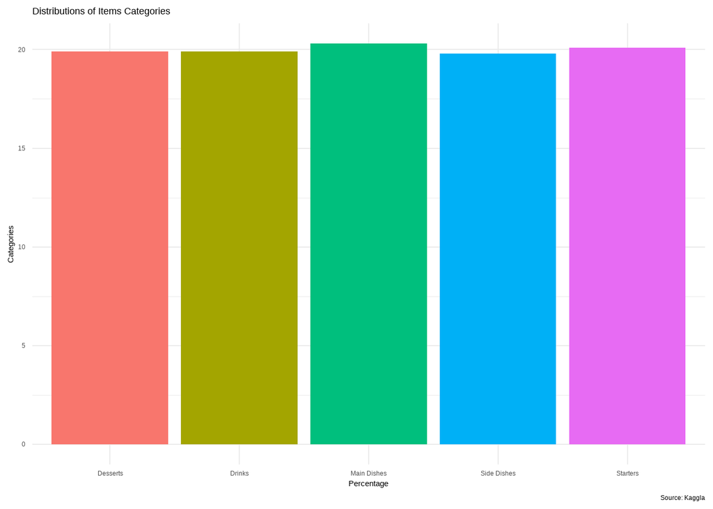

```r
clean_data %>%
  group_by(Category) %>%
  summarise(n = n()) %>%
  mutate(Percentage = round(n/sum(n),3)*100) %>%
  ggplot(aes(x = Category, y = Percentage ))+
  geom_bar(stat = "identity", aes(fill = Category), show.legend = F)+
  theme_minimal()+
    labs(title = "Distributions of Items Categories",
       y = "Categories", x = "Percentage", caption = "Source: Kaggla")
```

```r
clean_data %>%
  summarytools::descr(Price, stat = "common")
```

```
## Descriptive Statistics
## clean_data$Price
## N: 17534
##
##                      Price
## --------------- ----------
##            Mean       6.60
##         Std.Dev       4.86
##             Min       1.00
##          Median       5.00
##             Max      20.00
##         N.Valid   17534.00
##       Pct.Valid     100.00
```

**Observation:** The average price of items sold is **$6.60**, with a **standard deviation of $4.85**, indicating moderate variability in pricing. The **minimum price** observed is **$1.00**, while the **maximum** reaches **$20.00**, showing a wide range of item prices. The **median price** is **$5.00**, which is lower than the mean, suggesting a slight right-skew in the price distribution (i.e., a few higher-priced items pulling the average upward). All **17,534 observations** are valid, making up **100%** of the data, with no missing values for price.

```r
clean_data %>%
  summarytools::descr(Quantity, stat = "common")
```

```
## Descriptive Statistics
## clean_data$Quantity
## N: 17534
##
##                   Quantity
## --------------- ----------
##            Mean       3.01
##         Std.Dev       1.41
##             Min       1.00
##          Median       3.00
##             Max       5.00
##         N.Valid   17534.00
##       Pct.Valid     100.00
```

**Observation:** The average quantity of items ordered is **3.01**, with a **standard deviation of 1.42**, indicating a relatively consistent ordering pattern. The **minimum quantity** is **1**, and the **maximum** is **5**, suggesting that customers typically order between one and five items at a time. The **median quantity** is **3**, which aligns closely with the mean, indicating a fairly symmetrical distribution. All **17,534 observations** are valid, representing **100%** completeness for the `Quantity` variable.

```r
clean_data %>%
  summarytools::descr(Order.Total, stat = "common")
```

```
## Descriptive Statistics
## clean_data$Order.Total
## N: 17534
##
##                   Order.Total
## --------------- -------------
##            Mean         19.88
##         Std.Dev         18.81
##             Min          1.00
##          Median         15.00
##             Max        100.00
##         N.Valid      17534.00
##       Pct.Valid        100.00
```

**Observation:** The average order total is **$19.90**, with a **standard deviation of $18.83**, indicating considerable variability in how much customers spend per transaction. The **minimum order total** is **$1.00**, while the **maximum** reaches **$100.00**, showing a wide range of spending behavior. The **median** order total is **$15.00**, which is lower than the mean, suggesting a slight right-skew in the data due to some high-value orders. All **17,534 observations** are valid, reflecting **100%** data completeness for the `Order.Total` variable.

## Bivariate Analysis:

```r
clean_data %>%
  group_by(Item) %>%
  summarise(
    n = n(),
    `Total Quantity` = sum(Quantity, na.rm = TRUE)
  ) %>%
  mutate(`Average Quantity` = round(`Total Quantity` / n, 2)) %>%
  top_n(10, wt = `Total Quantity`) %>% kable()
```

| Item | n | Total Quantity | Average Quantity |
| --- | --- | --- | --- |
|  | 1758 | 5203 | 2.96 |
| Chocolate Cake | 798 | 2348 | 2.94 |
| Coca Cola | 756 | 2282 | 3.02 |
| French Fries | 897 | 2721 | 3.03 |
| Grilled Chicken | 822 | 2492 | 3.03 |
| Ice Cream | 936 | 2929 | 3.13 |
| Mashed Potatoes | 799 | 2374 | 2.97 |
| Pasta Alfredo | 998 | 3094 | 3.10 |
| Side Salad | 978 | 2932 | 3.00 |
| Water | 956 | 2899 | 3.03 |

```r
clean_data %>%
  group_by(Item) %>%
  summarise(
    n = n(),
    `Ordered Quantity` = sum(Order.Total, na.rm = TRUE)
  ) %>%
  mutate(`Average Quantity` = round(`Ordered Quantity` / n, 2)) %>%
  top_n(10, wt = `Ordered Quantity`) %>% kable()
```

| Item | n | Ordered Quantity | Average Quantity |
| --- | --- | --- | --- |
|  | 1758 | 33979.5 | 19.33 |
| Chicken Melt | 442 | 10640.0 | 24.07 |
| Chocolate Cake | 798 | 14088.0 | 17.65 |
| French Fries | 897 | 10884.0 | 12.13 |
| Grilled Chicken | 822 | 37380.0 | 45.47 |
| Ice Cream | 936 | 14645.0 | 15.65 |
| Pasta Alfredo | 998 | 37128.0 | 37.20 |
| Salmon | 422 | 22608.0 | 53.57 |
| Steak | 574 | 35320.0 | 61.53 |
| Vegetarian Platter | 382 | 15708.0 | 41.12 |

```r
clean_data %>%
  group_by(Category) %>%
  summarise(
    n = n(),
    `Total Quantity` = sum(Quantity, na.rm = TRUE)
  ) %>%
  mutate(`Average Quantity` = round(`Total Quantity` / n, 2)) %>%
  top_n(10, wt = `Total Quantity`) %>% kable()
```

| Category | n | Total Quantity | Average Quantity |
| --- | --- | --- | --- |
| Desserts | 3496 | 10522 | 3.01 |
| Drinks | 3488 | 10509 | 3.01 |
| Main Dishes | 3551 | 10825 | 3.05 |
| Side Dishes | 3472 | 10352 | 2.98 |
| Starters | 3527 | 10569 | 3.00 |

```r
clean_data %>%
  group_by(Category) %>%
summarise(
    n = n(),
    `Ordered Quantity` = sum(Order.Total, na.rm = TRUE)
  ) %>%
  mutate(`Average Quantity` = round(`Ordered Quantity` / n, 2)) %>%
  top_n(10, wt = `Ordered Quantity`) %>% kable()
```

| Category | n | Ordered Quantity | Average Quantity |
| --- | --- | --- | --- |
| Desserts | 3496 | 58826.5 | 16.83 |
| Drinks | 3488 | 24383.5 | 6.99 |
| Main Dishes | 3551 | 162381.5 | 45.73 |
| Side Dishes | 3472 | 41799.0 | 12.04 |
| Starters | 3527 | 61270.5 | 17.37 |

# Statistical Modeling and Inference

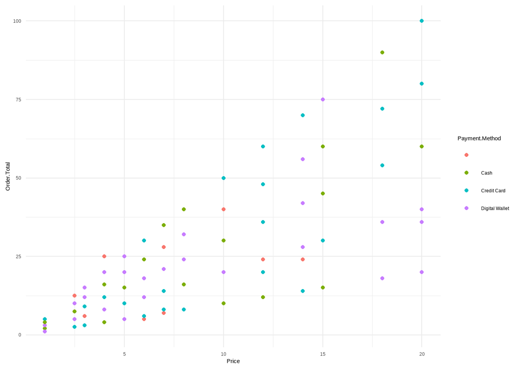

```r
clean_data %>%
  ggplot(aes(x = Price, y = Order.Total))+
  geom_point(aes(colour = Payment.Method))+
  theme_minimal()
```

```r
model<-lm(Order.Total~Price, data = clean_data)

summary(model)
```

```
##
## Call:
## lm(formula = Order.Total ~ Price, data = clean_data)
##
## Residuals:
##     Min      1Q  Median      3Q     Max
## -40.686  -5.936  -0.024   5.086  39.314
##
## Coefficients:
##             Estimate Std. Error t value Pr(>|t|)
## (Intercept) -0.19642    0.14758  -1.331    0.183
## Price        3.04413    0.01801 169.060   <2e-16 ***
## ---
## Signif. codes:  0 '***' 0.001 '**' 0.01 '*' 0.05 '.' 0.1 ' ' 1
##
## Residual standard error: 11.6 on 17532 degrees of freedom
## Multiple R-squared:  0.6198, Adjusted R-squared:  0.6198
## F-statistic: 2.858e+04 on 1 and 17532 DF,  p-value: < 2.2e-16
```